# Ford GoBike Trip Data Analysis

In this part of project, our goal is to conduct an exploratory data analysis on *Ford GoBike Trip dataset*. We will use Python data science and data visualization libraries to explore the dataset’s variables and understand the data’s structure, oddities, patterns and relationships. The analysis in this part is structured, going from simple univariate relationships up through multivariate relationships, but it does not need to be clean or perfect. This part of the project is gives opportunity to ask questions on data and make discoveries.

- Introduction
- Explanatory data analysis
- Conclusions

# Introduction

The *Ford GoBike Trip dataset* includes information about individual rides made in a bike-sharing system covering the greater San Francisco Bay & nearby areas. Each trip is anonymized and includes:

```
Trip Duration (seconds)
Start Time and Date
End Time and Date
Start Station ID
Start Station Name
Start Station Latitude
Start Station Longitude
End Station ID
End Station Name
End Station Latitude
End Station Longitude
Bike ID
User Type (Subscriber or Customer – “Subscriber” = Member or “Customer” = Casual)
Member Year of Birth
Member Gender
```

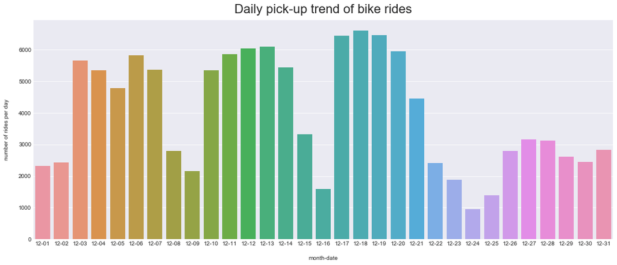

```python
plt.figure(figsize=(18,7))
sns.countplot(x='start_time_month_date', data=df.sort_values(by='start_time_month_date'))
plt.title('Daily pick-up trend of bike rides', fontsize=22, y=1.015)
plt.xlabel('month-date', labelpad=16)
plt.ylabel('number of rides per day', labelpad=16)
ax = plt.gca()
```

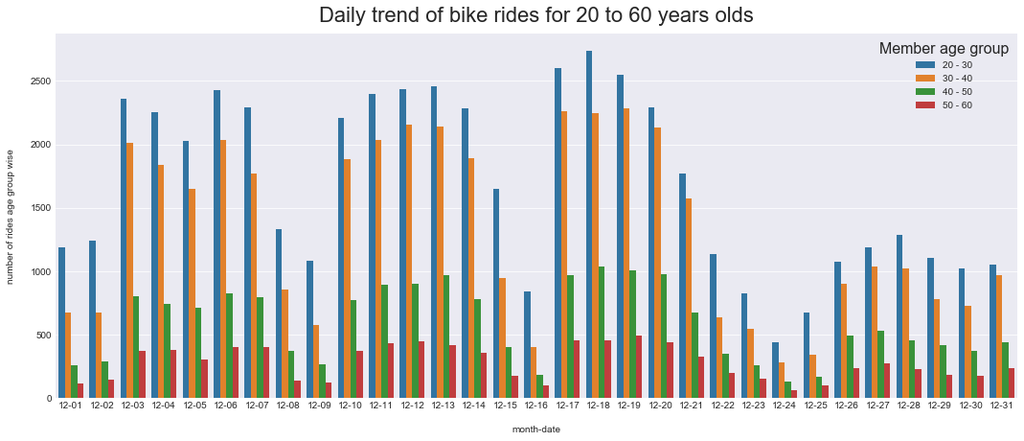

```python
plt.figure(figsize=(18,7))
ax = sns.countplot(x='start_time_month_date', hue='member_age_bins',
                   data=df[df['member_age_bins'].isin(
                       ['20 - 30', '30 - 40', '40 - 50', '50 - 60'])].sort_values(
                       by=['start_time_month_date', 'member_age_bins']))
plt.title('Daily trend of bike rides for 20 to 60 years olds', fontsize=22, y=1.015)
plt.xlabel('month-date', labelpad=16)
plt.ylabel('number of rides age group wise', labelpad=16)
leg = ax.legend()
leg.set_title('Member age group',prop={'size':16})
ax = plt.gca()
```

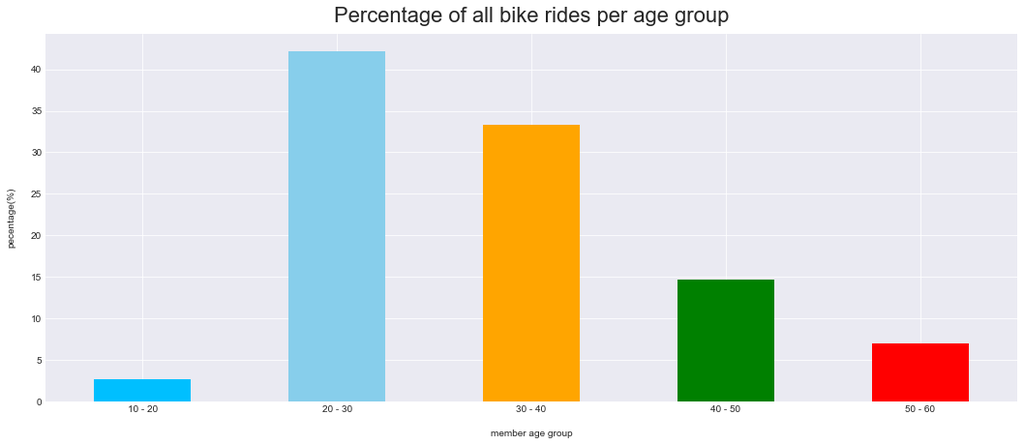

```python
trip_by_age_df = df.groupby('member_age_bins').agg({'bike_id':'count'})

trip_by_age_df['perc'] = (trip_by_age_df['bike_id']/trip_by_age_df['bike_id'].sum())*100

new_color = ['deepskyblue', 'skyblue', 'orange', 'green', 'red']
trip_by_age_df['perc'].plot(kind='bar',color=new_color, figsize=(18,7))
plt.title('Percentage of all bike rides per age group', fontsize=22, y=1.015)
plt.xlabel('member age group', labelpad=16)
plt.ylabel('pecentage(%)', labelpad=16)
plt.xticks(rotation=360)
```

[output not shown]

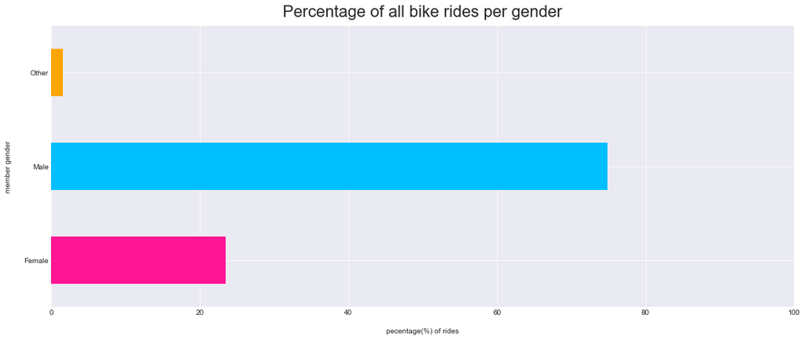

```python
trip_by_gender_df = df.groupby('member_gender').agg({'bike_id':'count'})

trip_by_gender_df['perc'] = (trip_by_gender_df['bike_id']/trip_by_gender_df['bike_id'].sum())*100

new_color = ['deeppink', 'deepskyblue', 'orange']
trip_by_gender_df['perc'].plot(kind='barh', color=new_color, figsize=(18,7))
plt.title('Percentage of all bike rides per gender', fontsize=22, y=1.015)
plt.ylabel('member gender', labelpad=16)
plt.xlabel('pecentage(%) of rides', labelpad=16)
plt.xticks(rotation=360)
plt.xlim(0,100)
```

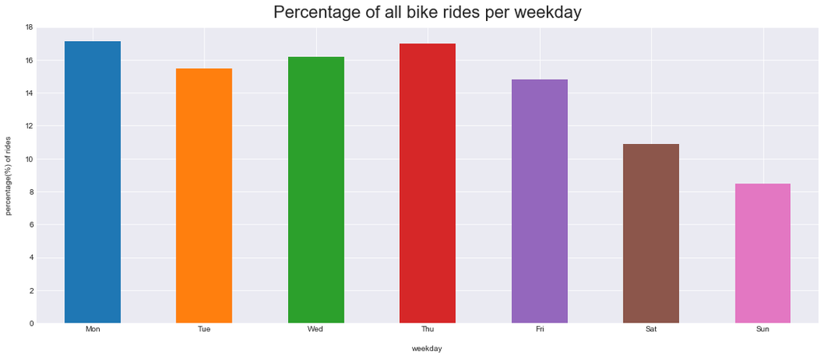

```python
trip_by_weekday_df = df.groupby('start_time_weekday_abbr').agg({'bike_id':'count'})

trip_by_weekday_df['perc'] = (trip_by_weekday_df['bike_id']/trip_by_weekday_df['bike_id'].sum())*100

weekday_index = ['Mon', 'Tue', 'Wed', 'Thu', 'Fri', 'Sat', 'Sun']

trip_by_weekday_df.reindex(weekday_index)['perc'].plot(kind='bar', figsize=(18,7), legend=False)
plt.title('Percentage of all bike rides per weekday', fontsize=22, y=1.015)
plt.xlabel('weekday', labelpad=16)
plt.ylabel('percentage(%) of rides', labelpad=16)
plt.xticks(rotation=360)
```

[output not shown]

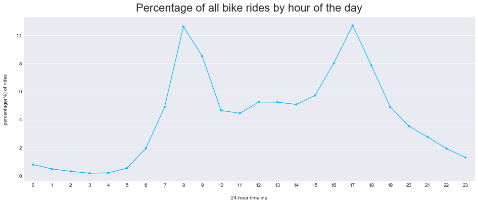

```python
trip_by_hour_df = df.groupby('start_time_hour').agg({'bike_id':'count'}).reset_index()

trip_by_hour_df['bike_id'] = (trip_by_hour_df['bike_id']/trip_by_hour_df['bike_id'].sum())*100

plt.figure(figsize=(16,6))
sns.pointplot(x='start_time_hour', y='bike_id', scale=.7, color='deepskyblue', data=trip_by_hour_df)
plt.title('Percentage of all bike rides by hour of the day', fontsize=22, y=1.015)
plt.xlabel('24-hour timeline', labelpad=16)
plt.ylabel('percentage(%) of rides', labelpad=16)
```

[output not shown]

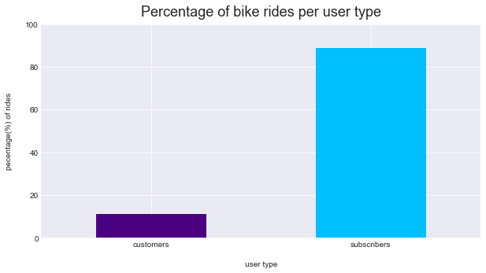

```python
count_of_rides_per_user_type = df.groupby('user_type').size().reset_index(name='count')

user_type = count_of_rides_per_user_type['count']/len(df)*100

new_color = ['indigo', 'deepskyblue']
user_type.plot(kind='bar', color=new_color, figsize=(10,5))
plt.title('Percentage of bike rides per user type', fontsize=18, y=1.015)
plt.ylabel('pecentage(%) of rides', labelpad=16)
plt.xlabel('user type', labelpad=16)
plt.xticks(np.arange(2), ('customers', 'subscribers'), rotation=360)
plt.ylim(0,100)
```

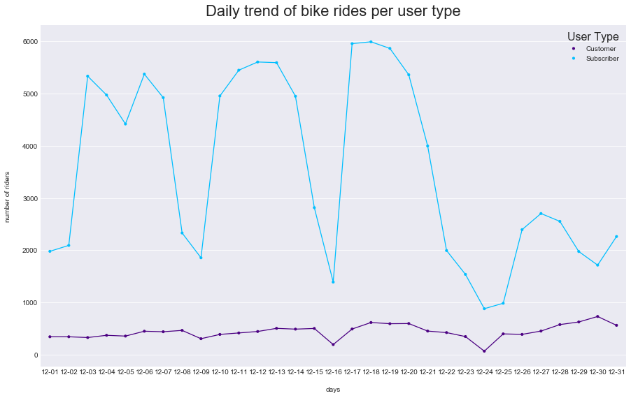

```python
user_type_count_per_year_df = df.groupby(["start_time_month_date", "user_type"]).size().reset_index()

plt.figure(figsize=(15,9))
my_palette = {'Subscriber':'deepskyblue', 'Customer':'indigo'}
ax = sns.pointplot(x='start_time_month_date', y=0, hue='user_type',
                   palette=my_palette, scale=.7, data=user_type_count_per_year_df)
plt.title('Daily trend of bike rides per user type', fontsize=22, y=1.015)
plt.xlabel('days', labelpad=16)
plt.ylabel('number of riders', labelpad=16)
leg = ax.legend()
leg.set_title('User Type',prop={'size':16})
ax = plt.gca()
```

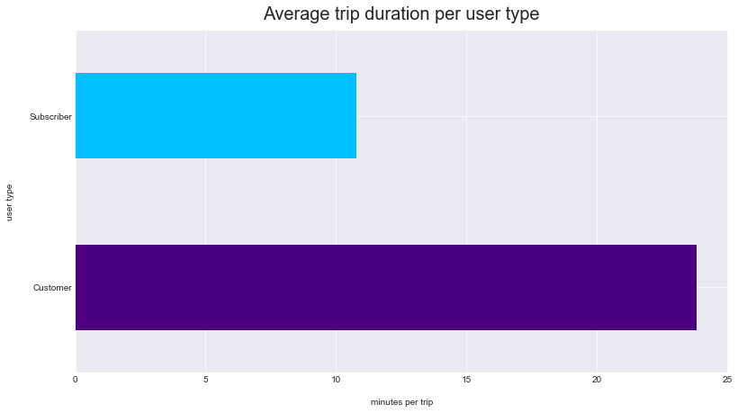

```python
new_color=['indigo', 'deepskyblue']
ax = df.groupby('user_type')['duration_min'].mean().plot(kind='barh', color=new_color, figsize=(13,7))
ax.set_title('Average trip duration per user type', fontsize=20, y=1.015)
ax.set_ylabel('user type', labelpad=16)
ax.set_xlabel('minutes per trip', labelpad=16)
ax = plt.gca()
```

[output not shown]

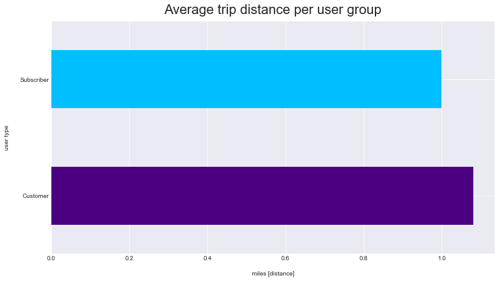

```python
ax = df.groupby('user_type')['distance_miles_estimates'].mean().plot(kind='barh', color=new_color, figsize=(13,7))
ax.set_title('Average trip distance per user group', fontsize=22, y=1.015)
ax.set_ylabel('user type', labelpad=16)
ax.set_xlabel('miles [distance]', labelpad=16)
```

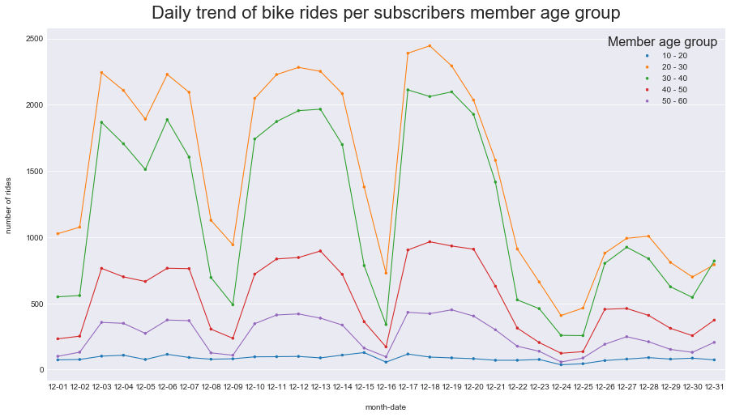

```python
subscriber_age_df = df[df['user_type']=='Subscriber'].groupby(
    ['start_time_month_date', 'member_age_bins']).agg({'bike_id':'count'}).reset_index()
plt.figure(figsize=(15,8))
ax = sns.pointplot(x='start_time_month_date', y='bike_id', hue='member_age_bins', scale=.6, data=subscriber_age_df)
plt.title("Daily trend of bike rides per subscribers member age group", fontsize=22, y=1.015)
plt.xlabel('month-date', labelpad=16)
plt.ylabel('number of rides', labelpad=16)
leg = ax.legend()
leg.set_title('Member age group',prop={'size':16})
ax = plt.gca()
```